# Project 4

## Project 4 - MISY408

Each row in the insurance dataset is associated with one person.

**Load insurance CSV File into df dataframe, take a deep copy of that and save it in df1 dataframe**

```python
import pandas as pd

df = pd.read_csv('insurance.csv')

df1 = df.copy()
```

**Import required libraries for visualization (matplotlib and seaborn)**

```python
import matplotlib.pyplot as plt
import seaborn as sns

# important: ensures the visualizations will be in the Notebook
%matplotlib inline
```

**Question 1:**

**Explore the dataframe: the shape of the df, the list of columns, check if there is any missing values**

```python
df.shape
```

```
(1338, 7)
```

```python
df.columns
```

```
Index(['age', 'sex', 'bmi', 'children', 'smoker', 'region', 'charges'], dtype='object')
```

```python
df.isnull().sum()
```

```
age         0
sex         0
bmi         0
children    0
smoker      0
region      0
charges     0
dtype: int64
```

**Question 2:**

**Generate the descriptive statistics to show count, mean, std, min, max, and etc. of age, bmi, children, and charges columns in the df1 dataframe**

```python
df1.describe().transpose()
```

|  | count | mean | std | min | 25% | 50% | 75% | max |
| --- | --- | --- | --- | --- | --- | --- | --- | --- |
| age | 1338.0 | 39.207025 | 14.049960 | 18.0000 | 27.00000 | 39.000 | 51.000000 | 64.00000 |
| bmi | 1338.0 | 30.663397 | 6.098187 | 15.9600 | 26.29625 | 30.400 | 34.693750 | 53.13000 |
| children | 1338.0 | 1.094918 | 1.205493 | 0.0000 | 0.00000 | 1.000 | 2.000000 | 5.00000 |
| charges | 1338.0 | 13270.422265 | 12110.011237 | 1121.8739 | 4740.28715 | 9382.033 | 16639.912515 | 63770.42801 |

**Question 3:**

**Create a histogram of bmi. The title should be 'BMI vs. Frequency', the x axis label should be 'BMI' and the y axis label should be 'Frequency'.** (use **matplotlib**)

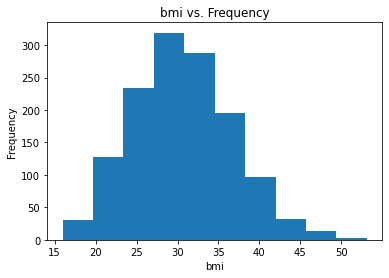

```python
plt.title('bmi vs. Frequency')
plt.xlabel('bmi')
plt.ylabel('Frequency')
plt.hist(df1['bmi'])
plt.show()
```

**Question 4:**

**Create a scatter plot of bmi vs. charges. The title should be bmi vs. charges.** (use **seaborn**).

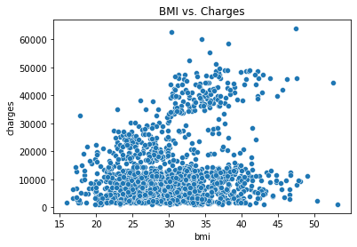

```python
sns.scatterplot(x=df1['bmi'], y=df1['charges']).set_title('BMI vs. Charges')
```

**Question 5:**

**Create a scatter plot of bmi vs. charges and add regression line to show strength of the relationship. The title should be bmi vs. charges**. (use **seaborn**).

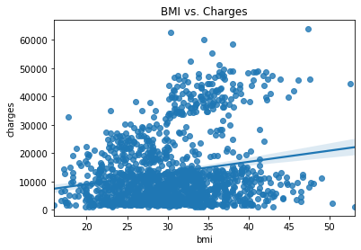

```python
sns.regplot(x=df1['bmi'], y=df1['charges']).set_title('BMI vs. Charges')
```

**Question 6:**

**Create a scatter plot of bmi vs. charges and change the color of dots by 'smoker' column. The title should be bmi vs. charges.** (use **seaborn** )

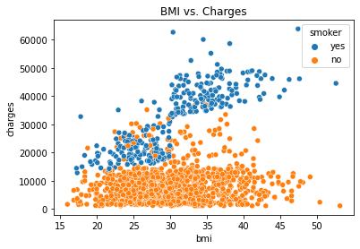

```python
sns.scatterplot(x=df1['bmi'], y=df1['charges'], hue=df1['smoker']).set_title('BMI vs. Charges')
```

**Question 7:**

**Use pairplot to generate scatterplots of all variables (age, bmi, children, and charges), pairwise**

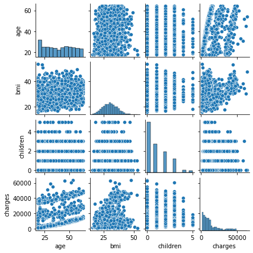

```python
sns.pairplot(df1[['age', 'sex', 'bmi', 'children', 'smoker', 'region', 'charges']], height=1.5)
```

**Question 8:**

**Generate the correlation matrix Heatmap for df1 dataframe**

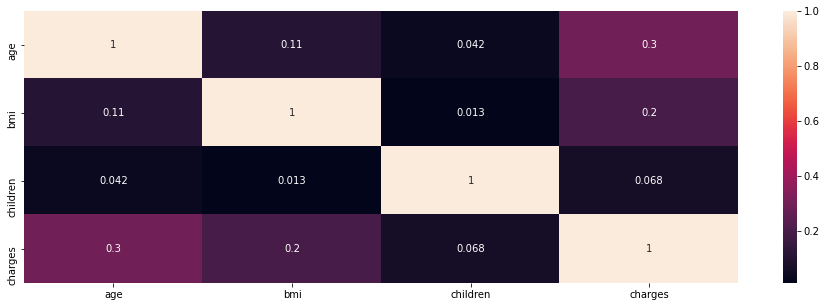

```python
plt.figure(figsize=(16,5))
sns.heatmap(df1.corr(), annot = True)
```

**Question 9:**

**Create a bar chart to show the number of people from each region. The title should be 'region vs. Frequency', the x axis label should be 'region' and y axis label should be 'Frequency'** (use **matplotlib**) (the color of bars can be any color)

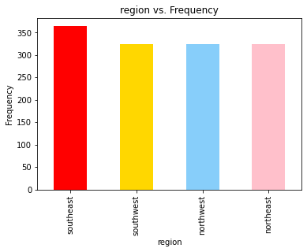

```python
plt.title('region vs. Frequency')
plt.xlabel('region')
plt.ylabel('Frequency')
colors = ['red', 'gold', 'lightskyblue','pink','blue', 'darkgreen','yellow','grey']

df1['region'].value_counts().plot(kind='bar', color=colors)
```

**Question 10:**

**Create a pie chart to show the percentage of people from each region. The slices should have labels** (use **matplotlib**).

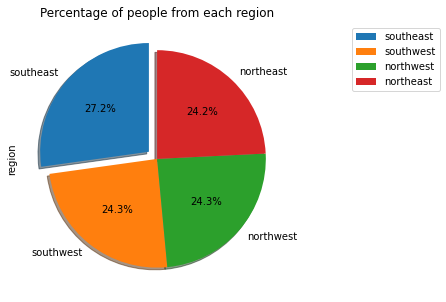

```python
plt.title('Percentage of people from each region')
plt.title('Percentage of people from each region')
explode_list = [.1,0,0,0]

df1['region'].value_counts().plot(kind='pie',
                            figsize=(5, 5),
                            autopct='%0.1f%%',
                            startangle=90,
                            shadow=True,
                            explode=explode_list
                            )
plt.legend(df1['region'].value_counts().index,bbox_to_anchor=(1.2,1))
```

**Question 11:**

**Create a countplot to show the number of people in each region. Change the color with smoker (the x axis should be region)**

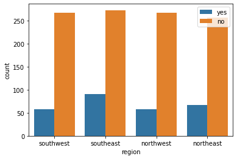

```python
sns.countplot(x=df1['region'], hue=df1['smoker'])
plt.legend(loc='upper right')
```

**Question 12**

**Create a line plot to show average bmi for different ages.**

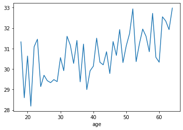

```python
df1['bmi'].groupby(df1['age']).mean().plot(kind='line')
```

**Question 13**

**Create a line plot to show average bmi for different ages. Change the color of line with smoker column.**

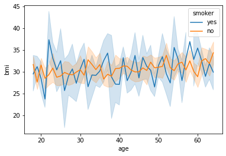

```python
sns.lineplot(x=df1['age'], y=df1['bmi'], hue=df1['smoker'], estimator='mean')
```